# Causal Implicature - Pilot data analysis

Author

MF

```r
library(tidyverse)
library(tidyboot)
library(aida)
library(brms)
library(faintr)
library(patchwork)

##################################################

# these options help Stan run faster
options(mc.cores = parallel::detectCores())

# use the aida-theme for plotting
theme_set(theme_aida())

# global color scheme / non-optimized
project_colors = c("#E69F00", "#56B4E9", "#009E73",
                   "#F0E442", "#0072B2", "#D55E00",
                   "#CC79A7", "#000000")

# setting theme colors globally
scale_colour_discrete <- function(...) {
  scale_colour_manual(..., values = project_colors)
}
scale_fill_discrete <- function(...) {
  scale_fill_manual(..., values = project_colors)
}

##################################################

d1 <- read_csv('01-wrangled-data-pilot-1a.csv')
d2 <- read_csv('01-wrangled-data-pilot-1b.csv')

d = d1
```

Two pilot studies were run to test whether a statement like “X is associated with Y”, which strictly speaking does not entail a causal relationship between X and Y, can nonetheless convey or suggest a causal connection. The only difference between the studies is the exclusion or inclusion of additional information in the context description (see below).

## Study details

N=200 participants recruited via Prolific (English Native, at least 10 previous studies, at least 90% approval rate). For technical reasons, N=198 data sets were received for pilot 1a, and N=203 for pilot 1b. Participants took about 2.69 for pilot 1a, and about 2.69 minutes for pilot 1b on average. They were paid 0.4 British Pounds.

The experiment code, data an material are [available online](https://github.com/magpie-ea/magpie3-causal-implicature). A live version of the experiment can be tested [here](https://magpie-ea.github.io/magpie3-causal-implicature/).

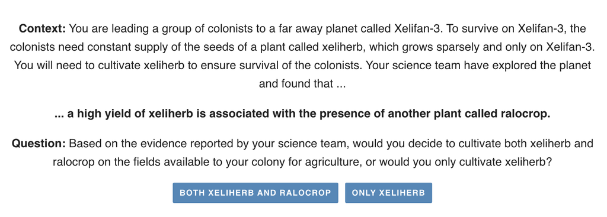

Figure 1: Screenshot from a trial in condition ‘association’ for Pilot 1a.

The four conditions differed with respect to the sentence in bold in the screenshot in Figure Figure 1, like so:

- **association**: … a high yield of xeliherb is associated with the presence of another plant called ralocrop.
- **intervention**: … a high yield of xeliherb was obtained whenever another plant called ralocrop was cultivated as well.
- **commonCause**: … a high yield of xeliherb is associated with the presence of another plant called ralocrop. But they also found that ralocrop only grows on particularly fertile grounds.
- **deniedCausality**: … a high yield of xeliherb is associated with the presence of another plant called ralocrop. But there is no evidence that the cultivation of ralocrop causes a better yield of xeliherb.

In Pilot 1b, participants received another piece of explicit background information, namely that cultivation of ralocrop incurs a cost, as shown in Figure Figure 2

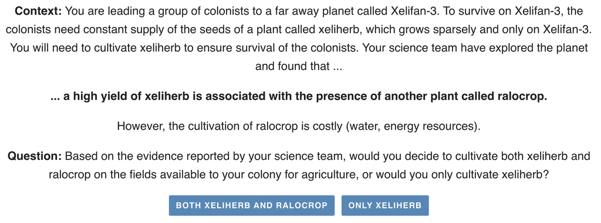

Figure 2: Screenshot from a trial in condition ‘association’ for Pilot 1b. Notice the additional sentence after the critical sentence in bold.

The relevant condition of interest is **association**. The other conditions function as reference categories. We expect different degrees of belief in the relevant causal relation (ralocrop causes a high yield of xeliherb) after processing different statements by the science team (= different experimental conditions). The auxiliary assumption is that the more participants put faith in the relevant causal relation, they should be more inclined to select the “BOTH” option. Concretely, we therefore expect higher choice rates of the “both” option in the **association** condition than in the **deniedCausality** condition; thus, this latter condition provides a potential lower bound of causal implicature strength. An upper bound would be given by the **intervention** condition, which we predict to have highest choice rates of “BOTH”.

## Results

The proportion of choice of the “BOTH” option across conditions is shown in Figure Figure 3.

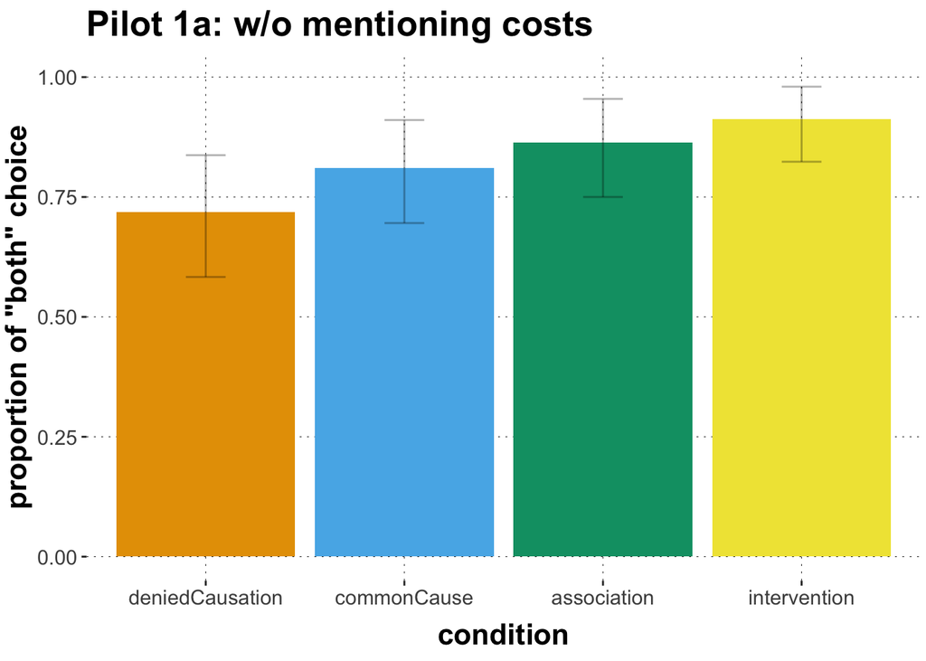

(a) Pilot 1a

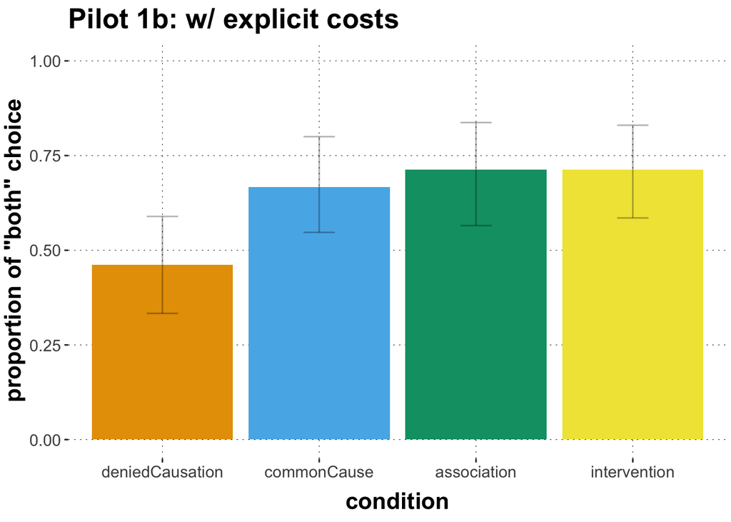

(b) Pilot 1b

Figure 3: Proportion of choice of ‘BOTH’ option per condition (with bootstrapped 95% CIs).

Descriptively, the order of choice rates across conditions matches expectations. We also see that mentioning a potential cost of ralocrop decreases the overall choice of the “BOTH” condition, which is intuitive.

For statistical analysis, we first look at the data from both pilot studies combined. We find that, indeed, choice rates of “BOTH” were credibly lower in pilot 1b. We also find that, for the pooled data, the **association** condition has a credibly higher rate of “BOTH” choices than the **deniedCausation** condition, but it is not credibly different from the **commonCause** condition or the **intervention** condition.

```r
run_regression_single <- function(d) {
  # run regression model for data from a single pilot version
  fit <- brm(decision ~ condition,
             family = bernoulli(link = "logit"),
             data = d %>% mutate(decision = factor(decision, levels = c("single", "both"))))
  fit
}

run_regression_joint <- function(d) {
  # run regression model for all of the data
  fit <- brm(decision ~ condition * version,
             family = bernoulli(link = "logit"),
             data = d %>% mutate(decision = factor(decision, levels = c("single", "both"))))
  fit
}

fit1 <- run_regression_single(d1)
fit2 <- run_regression_single(d2)
fit_joint <- run_regression_joint(rbind(d1,d2))
```

```r
evaluate_fit_joint <- function(fit) {
  # collect info on relevant contrasts (for all of the data at once)

  deniedCausationVScommonCause <- faintr::compare_groups(
    fit,
    lower = condition == "deniedCausation",
    higher  = condition == "commonCause"
  )

  commonCauseVSassociation <- faintr::compare_groups(
    fit,
    lower = condition == "commonCause",
    higher  = condition == "association"
  )

  associationVSintervention <- faintr::compare_groups(
    fit,
    lower = condition == "association",
    higher  = condition == "intervention"
  )

  deniedCaustaionVSassociation <- faintr::compare_groups(
    fit,
    lower = condition == "deniedCausation",
    higher  = condition == "association"
  )

  deniedCausationVSintervention <- faintr::compare_groups(
    fit,
    lower = condition == "deniedCausation",
    higher  = condition == "intervention"
  )

  pilot1aVSpilot1b <- faintr::compare_groups(
    fit,
    lower = version == "pilot-1b",
    higher = version == "pilot-1a"
  )

  tribble(
    ~comparison, ~posterior, ~"95%HDI (low)", ~"95%HDI (high)",
    "pilot 1b < pilot 1a" , pilot1aVSpilot1b$post_prob, pilot1aVSpilot1b$l_ci, pilot1aVSpilot1b$u_ci,
    "denied causation < common cause" , deniedCausationVScommonCause$post_prob, deniedCausationVScommonCause$l_ci, deniedCausationVScommonCause$u_ci,
    "common cause < association" , commonCauseVSassociation$post_prob, commonCauseVSassociation$l_ci, commonCauseVSassociation$u_ci,
    "association < intervention" , associationVSintervention$post_prob, associationVSintervention$l_ci, associationVSintervention$u_ci,
    "denied causation < association" , deniedCaustaionVSassociation$post_prob, deniedCaustaionVSassociation$l_ci, deniedCaustaionVSassociation$u_ci,
    "denied causation < intervention" , deniedCausationVSintervention$post_prob, deniedCausationVSintervention$l_ci, deniedCausationVSintervention$u_ci,
  )
}

knitr::kable(evaluate_fit_joint(fit_joint))
```

| comparison | posterior | 95%HDI (low) | 95%HDI (high) |
| --- | --- | --- | --- |
| pilot 1b < pilot 1a | 1.00000 | 0.5908640 | 1.6076583 |
| denied causation < common cause | 0.98950 | 0.1216612 | 1.3155417 |
| common cause < association | 0.81000 | -0.4142088 | 0.9977699 |
| association < intervention | 0.75425 | -0.5851821 | 1.0607171 |
| denied causation < association | 0.99975 | 0.3590098 | 1.7121386 |
| denied causation < intervention | 1.00000 | 0.6034550 | 2.0521252 |

For completeness, we also look at the data from each pilot version in isolation. For Pilot 1a, the picture is as follows:

```r
evaluate_fit <- function(fit) {
  # collect pairwise comparisons

  deniedCausationVScommonCause <- faintr::compare_groups(
    fit,
    lower = condition == "deniedCausation",
    higher  = condition == "commonCause"
  )

  commonCauseVSassociation <- faintr::compare_groups(
    fit,
    lower = condition == "commonCause",
    higher  = condition == "association"
  )

  associationVSintervention <- faintr::compare_groups(
    fit,
    lower = condition == "association",
    higher  = condition == "intervention"
  )

  deniedCaustaionVSassociation <- faintr::compare_groups(
    fit,
    lower = condition == "deniedCausation",
    higher  = condition == "association"
  )

  deniedCausationVSintervention <- faintr::compare_groups(
    fit,
    lower = condition == "deniedCausation",
    higher  = condition == "intervention"
  )

  tribble(
    ~comparison, ~posterior, ~"95%HDI (low)", ~"95%HDI (high)",
    "denied causation < common cause" , deniedCausationVScommonCause$post_prob, deniedCausationVScommonCause$l_ci, deniedCausationVScommonCause$u_ci,
    "common cause < association" , commonCauseVSassociation$post_prob, commonCauseVSassociation$l_ci, commonCauseVSassociation$u_ci,
    "association < intervention" , associationVSintervention$post_prob, associationVSintervention$l_ci, associationVSintervention$u_ci,
    "denied causation < association" , deniedCaustaionVSassociation$post_prob, deniedCaustaionVSassociation$l_ci, deniedCaustaionVSassociation$u_ci,
    "denied causation < intervention" , deniedCausationVSintervention$post_prob, deniedCausationVSintervention$l_ci, deniedCausationVSintervention$u_ci,
  )
}

knitr::kable(evaluate_fit(fit1))
```

| comparison | posterior | 95%HDI (low) | 95%HDI (high) |
| --- | --- | --- | --- |
| denied causation < common cause | 0.85900 | -0.4378585 | 1.372312 |
| common cause < association | 0.78225 | -0.6343304 | 1.603760 |
| association < intervention | 0.76350 | -0.8160401 | 1.948606 |
| denied causation < association | 0.96400 | -0.0601220 | 2.113571 |
| denied causation < intervention | 0.99300 | 0.3139540 | 2.784136 |

For the data from Pilot 1b, the results look as follows:

```r
knitr::kable(evaluate_fit(fit2))
```

| comparison | posterior | 95%HDI (low) | 95%HDI (high) |
| --- | --- | --- | --- |
| denied causation < common cause | 0.98575 | 0.0604142 | 1.6193541 |
| common cause < association | 0.69150 | -0.6334453 | 1.0939440 |
| association < intervention | 0.51800 | -0.9159289 | 0.9157533 |
| denied causation < association | 0.99475 | 0.2569859 | 1.9838505 |
| denied causation < intervention | 0.99550 | 0.2304369 | 1.9341103 |

## Interpretation

On the assumption that variation in the rate of “BOTH” choices is mostly explained by the varying strength of a “causal implicature”, i.e., a variable degree of belief in the relevant causal relationship, the data provides suggestive evidence that “causal implicatures” are triggered at different degrees by different linguistic expressions. In any case, the data warrant the conclusion that the manner in which a hypothetical “Science Team” delivers information about a statistical association might systematically influence a decision maker’s policy choice. Even in the case of a pure association statement (the **association** condition), participants endorsed the critical “BOTH” option more than when a direct causal link was denied.

## Participants’ justification of their choices

After giving the binary choice, participants were asked to give a justification for their decision. These are listed in full below.

While some justifications may hint at participants insufficient understanding of the scenario, it is still worth noting what they would choose based on their understanding, as insufficient understanding may also happen in “real-life” cases. On the other hand, it is interesting to see that some participants explicitly justify their “BOTH” decision in the **association** condition in terms of a causal relations (e.g., submission IDs 3901, 3906, … from Pilot 1a).

Also interesting, some participants seemed to have reasoned about causal structure at a different level, e.g., submission ID 3889 in the **commonCause** condition seems to have reasoned about relocrop causing the fertility of the ground in the long run.

```r
justifications <- rbind(d1,d2) %>%
  select(version, submission_id, condition, decision, justification) %>%
  arrange(version,decision, condition, submission_id)

knitr::kable(justifications)
```

| version | submission_id | condition | decision | justification |
| --- | --- | --- | --- | --- |
| pilot-1a | 3891 | association | both | On the information provided it seems that there is a better chance of having a good crop of Xeliherb and therefore sufficient seeds for the colonists if both plants are cultivated. |
| pilot-1a | 3895 | association | both | Best to grow both and have options |
| pilot-1a | 3896 | association | both | To get a better crop I choose to cultivate both |
| pilot-1a | 3900 | association | both | The plant grows sparsely, so to get a higher yield it would make sense to grow both types. |
| pilot-1a | 3901 | association | both | Because in order for the constant supply, both are needed as one cultivates the other. |
| pilot-1a | 3906 | association | both | To ensure that some deli herb grows as they could be dependent |
| pilot-1a | 3907 | association | both | Because cultivating Ralocrop as well would encourage having more of the needed crop Xelicrop (sp?). |
| pilot-1a | 3909 | association | both | Given that ralocrop helps the yield of xeloherb it makes sense to also cultivate that, even if it doesn’t have any direct use it will help get more of the seeds we do need |
| pilot-1a | 3910 | association | both | to ensure the survival of the colonists but also for the other plant that they just found growing there might make their dependency lower on the other plant |
| pilot-1a | 3911 | association | both | Cultivating both will yield higher levels of the one needed. |
| pilot-1a | 3915 | association | both | Because it’s better to give us the best chance by looking at all options |
| pilot-1a | 3916 | association | both | Because you need both to survive |
| pilot-1a | 3919 | association | both | it was explained in the description both produced the same |
| pilot-1a | 3925 | association | both | If a positive link has been found between both plants, and no negatives have been discovered from also cultivating the second plant, I see no reason not to cultivate both. |
| pilot-1a | 3926 | association | both | You need to cultivate both crops to maximise production |
| pilot-1a | 3927 | association | both | If the batch of the essential plant doesn’t grow properly then at least there is a plan B where it is likely to grow again. |
| pilot-1a | 3928 | association | both | If xeliherb cultivation is higher near ralocrop, that would increase my chances of growing my required herb. |
| pilot-1a | 3931 | association | both | To ensure a high yield of the crop necessary for survival. |
| pilot-1a | 3936 | association | both | In order to get a high yield of what we need, Ralacor is necessary. Seems like the smartest thing to do. |
| pilot-1a | 3940 | association | both | Ralocorp might be beneficial for the growth of xeliherb |
| pilot-1a | 3942 | association | both | I would cultivate both as I think that a higher yield when grown together would be more beneficial and then the other herb assuming it cannot be used for food, could be used for something else such as… |
| pilot-1a | 3951 | association | both | Because it states that to get a high yield of one crop, the presence of the other crop is needed |
| pilot-1a | 3954 | association | both | Sounds like they are companion plants - supporting the growth of each other. You also didn’t proved any information that the other plant was one we didn’t want to cultivate. |
| pilot-1a | 3957 | association | both | As they are both growing together, it would be sensible to assume there is possibly a beneficial relationship between these plants, therefore it is sensible to give the plants the best chance to culti… |
| pilot-1a | 3963 | association | both | As the presence of the other herb increases yield of the herb we need, I would hope the increase in yield would exceed the usage of space by the second herb if managed correctly. |
| pilot-1a | 3964 | association | both | I actually think I would need more info to make the decision, as it isn’t clear whether we would be cultivating a weed that grows alongside xeliherb but gives no benefit, or whether it is something th… |
| pilot-1a | 3971 | association | both | because I would want a high yield of the plant necessary for our survival. if it takes two plants that’s fine |
| pilot-1a | 3972 | association | both | This is because the two plants are codependent and thus both plants are needed for survival |
| pilot-1a | 3973 | association | both | It is dependant on the other to grow |
| pilot-1a | 3983 | association | both | Because they were always found together and you would assume they are codependent |

[output cut: 372 more lines]